BLOQUE 2 DE 6

Qué es una componente principal

De la intuición en dos dimensiones al caso general.

# En 2D: la dirección de máxima varianza

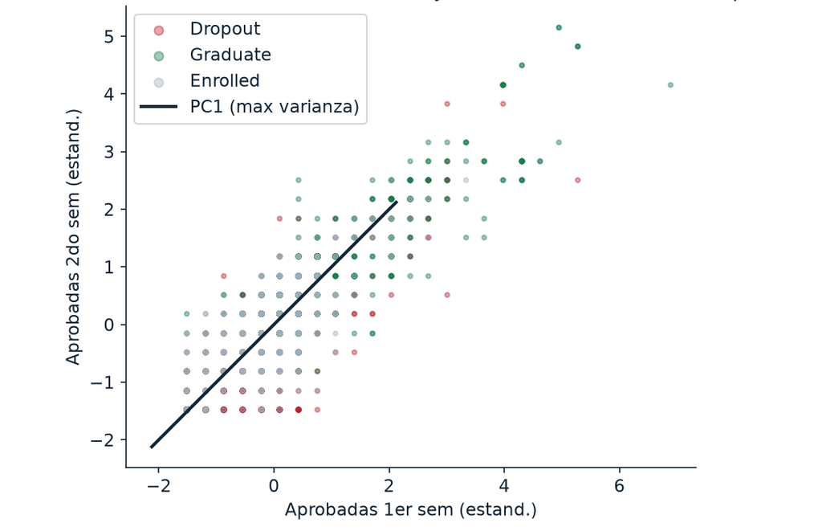

Materias aprobadas en 1er y 2do semestre (estandarizadas). La recta negra es la **primera componente**: la dirección a lo largo de la cual los puntos varían más. Ella sola concentra el 95,2% de la variabilidad de las dos variables.

# …y a la vez la recta más cercana a los puntos

Se gradúaAbandonaSigue cursando

Varianza capturada por la proyección

Error de proyección (los segmentos rojos)

Ángulo: **0°** — óptimo en **45°**

Arrastrá el ángulo (o apretá "Girar"). Los **segmentos rojos** son los errores de proyección: cuando la recta llega a la primera componente, esos errores alcanzan su **mínimo** y, en ese mismo instante, las proyecciones quedan lo más dispersas posible.

# Dos lecturas del mismo problema

Máxima varianza

La dirección a lo largo de la cual los datos proyectados tienen la **mayor dispersión** posible.

Mínima distancia

La recta que **minimiza** la suma de distancias al cuadrado entre cada punto y su proyección.

- Las dos definiciones llevan a la misma solución matemática.
- No es casualidad: la varianza total es fija, así que todo lo que la proyección captura es exactamente lo que el error deja de perder.
- Volvemos sobre esto en el Bloque 4, ya con números.

# En 3D: dos componentes definen un plano

# Una componente es una combinación lineal

1. $\textcolor{#31A354}{X_1,\dots,X_p}$ son las variables originales, ya centradas en media cero;
2. los *loadings* $\textcolor{#3182BD}{\phi_{jm}}$ son los **pesos**: cuánto aporta cada variable a la componente $m$;
3. los *scores* $\textcolor{#756BB1}{Z_m}$ son los **valores** resultantes: la posición de cada estudiante en esa nueva variable.

Usá **→** para ir revelando los términos.

Los loadings describen **variables**; los scores describen **observaciones**. Es la distinción que hace legible un biplot.

# Por qué los pesos se normalizan

- Se exige que la suma de los cuadrados de los pesos sea **igual a 1**.
- Sin esa restricción el problema no tendría solución: agrandando los pesos, la varianza crecería sin límite.
- Normalizar obliga a buscar una **dirección** en el espacio de las variables, no una magnitud arbitraria.

Cómo se calcula en la práctica

Los pesos salen de la **descomposición en autovectores y autovalores** de la matriz de covarianzas (o de correlaciones, si estandarizamos). Cada componente es un **autovector**; la varianza que explica es su **autovalor**. No hace falta resolverlo a mano: lo hace la función de PCA.

# Cada componente es ortogonal a las anteriores

- La segunda componente se busca igual que la primera, maximizando varianza, pero con una condición extra: ser ortogonal (no correlacionada) con la primera.
- Lo mismo para la tercera respecto de las dos anteriores, y así sucesivamente.
- Cada una captura **información nueva**, no una repetición de la anterior.
- En total hay como máximo $\min(n-1,\,p)$ componentes. Con nuestras 8 variables, **8 componentes**.

Usar *todas* las componentes no pierde nada: es solo **rotar** el sistema de coordenadas. La compresión aparece cuando nos quedamos con algunas.

# El score de un estudiante, término a término

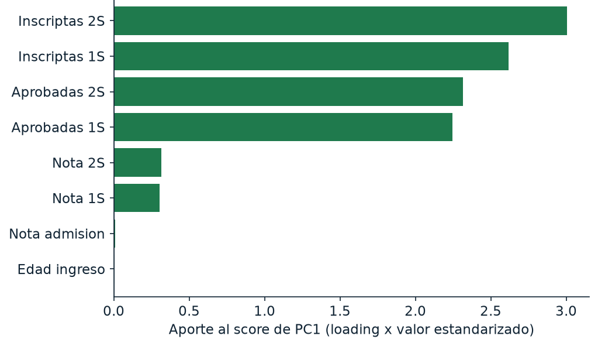

Aporte de cada variable al score en PC1 de un estudiante concreto: su **valor estandarizado por el loading** de esa variable. Las cuatro variables de materias explican casi todo el score; la nota de admisión y la edad, prácticamente nada.

# Las componentes están definidas salvo el signo

Un detalle que confunde

Dos programas pueden devolver la **misma componente con el signo invertido**, y ambos son correctos.

- Un vector de pesos define una **dirección**, y una dirección se extiende hacia los dos lados.
- Dar vuelta el signo de los loadings y el de los scores a la vez deja **todo igual**.
- Lo que importa es la **geometría relativa**: qué variables van juntas y cuáles se oponen.
- En la práctica conviene **orientar** cada componente para que se lea bien, como hicimos al poner el éxito académico hacia la derecha.

A la notebook

Calcular un score **a mano** y comprobar que coincide con el del algoritmo.

También: rotar la recta y ver cómo cambia la varianza proyectada.